## 빅데이터통계분석_실습과제_1조

### (김상명, 이지현, 조준영, 채지혜, 한혜림)

### 문제 1 : 약수와 소수 구하기

- n이 입력값으로 주어질 때 약수의 개수를 출력하는 함수를 완성하시오.
  - 예) div_count(n)
- n이 입력값으로 주어질 때 소수의 개수를 출력하는 함수를 완성하시오.
  - 예) prime_count(n)
  - div_count()와 sapply() 함수를 이용할 수 있다.
  - (소수는 약수의 개수가 2개인 수라는 사실을 이용해 볼 것.)

```r
# n이 입력값으로 주어질 때 약수의 개수를 출력하는 함수

# 약수
div_count <- function(n)sum(n%%(1:n) == 0)

# 소수
prime_count <- function(n)sum(sapply(2:n, div_count) == 2)

div_count(2)
```

```
## [1] 2
```

```r
div_count(9)
```

```
## [1] 3
```

```r
div_count(10)
```

```
## [1] 4
```

```r
div_count(100)
```

```
## [1] 9
```

```r
prime_count(10)
```

```
## [1] 4
```

```r
prime_count(100)
```

```
## [1] 25
```

### 문제 2: mtcars 데이터셋

```r
# mtcars 데이터셋의 구조를 확인하시오.
str(mtcars)
```

```
## 'data.frame':    32 obs. of  11 variables:
##  $ mpg : num  21 21 22.8 21.4 18.7 18.1 14.3 24.4 22.8 19.2 ...
##  $ cyl : num  6 6 4 6 8 6 8 4 4 6 ...
##  $ disp: num  160 160 108 258 360 ...
##  $ hp  : num  110 110 93 110 175 105 245 62 95 123 ...
##  $ drat: num  3.9 3.9 3.85 3.08 3.15 2.76 3.21 3.69 3.92 3.92 ...
##  $ wt  : num  2.62 2.88 2.32 3.21 3.44 ...
##  $ qsec: num  16.5 17 18.6 19.4 17 ...
##  $ vs  : num  0 0 1 1 0 1 0 1 1 1 ...
##  $ am  : num  1 1 1 0 0 0 0 0 0 0 ...
##  $ gear: num  4 4 4 3 3 3 3 4 4 4 ...
##  $ carb: num  4 4 1 1 2 1 4 2 2 4 ...
```

```r
# mtcars 데이터셋의 요약정보를 확인하시오.
summary(mtcars)
```

```
##       mpg             cyl             disp             hp
##  Min.   :10.40   Min.   :4.000   Min.   : 71.1   Min.   : 52.0
##  1st Qu.:15.43   1st Qu.:4.000   1st Qu.:120.8   1st Qu.: 96.5
##  Median :19.20   Median :6.000   Median :196.3   Median :123.0
##  Mean   :20.09   Mean   :6.188   Mean   :230.7   Mean   :146.7
##  3rd Qu.:22.80   3rd Qu.:8.000   3rd Qu.:326.0   3rd Qu.:180.0
##  Max.   :33.90   Max.   :8.000   Max.   :472.0   Max.   :335.0
##       drat             wt             qsec             vs
##  Min.   :2.760   Min.   :1.513   Min.   :14.50   Min.   :0.0000
##  1st Qu.:3.080   1st Qu.:2.581   1st Qu.:16.89   1st Qu.:0.0000
##  Median :3.695   Median :3.325   Median :17.71   Median :0.0000
##  Mean   :3.597   Mean   :3.217   Mean   :17.85   Mean   :0.4375
##  3rd Qu.:3.920   3rd Qu.:3.610   3rd Qu.:18.90   3rd Qu.:1.0000
##  Max.   :4.930   Max.   :5.424   Max.   :22.90   Max.   :1.0000
##        am              gear            carb
##  Min.   :0.0000   Min.   :3.000   Min.   :1.000
##  1st Qu.:0.0000   1st Qu.:3.000   1st Qu.:2.000
##  Median :0.0000   Median :4.000   Median :2.000
##  Mean   :0.4062   Mean   :3.688   Mean   :2.812
##  3rd Qu.:1.0000   3rd Qu.:4.000   3rd Qu.:4.000
##  Max.   :1.0000   Max.   :5.000   Max.   :8.000
```

```r
# gear의 개수가 4인 자동차 모델의 모든 열 정보를 추출하시오.
mtcars[mtcars$gear==4,]
```

```
##                 mpg cyl  disp  hp drat    wt  qsec vs am gear carb
## Mazda RX4      21.0   6 160.0 110 3.90 2.620 16.46  0  1    4    4
## Mazda RX4 Wag  21.0   6 160.0 110 3.90 2.875 17.02  0  1    4    4
## Datsun 710     22.8   4 108.0  93 3.85 2.320 18.61  1  1    4    1
## Merc 240D      24.4   4 146.7  62 3.69 3.190 20.00  1  0    4    2
## Merc 230       22.8   4 140.8  95 3.92 3.150 22.90  1  0    4    2
## Merc 280       19.2   6 167.6 123 3.92 3.440 18.30  1  0    4    4
## Merc 280C      17.8   6 167.6 123 3.92 3.440 18.90  1  0    4    4
## Fiat 128       32.4   4  78.7  66 4.08 2.200 19.47  1  1    4    1
## Honda Civic    30.4   4  75.7  52 4.93 1.615 18.52  1  1    4    2
## Toyota Corolla 33.9   4  71.1  65 4.22 1.835 19.90  1  1    4    1
## Fiat X1-9      27.3   4  79.0  66 4.08 1.935 18.90  1  1    4    1
## Volvo 142E     21.4   4 121.0 109 4.11 2.780 18.60  1  1    4    2
```

```r
# gear의 개수가 4인 자동차 모델의 mpg, cyl, hp, wt 열 정보만 추출하시오.
mtcars[mtcars$gear==4,c('mpg', 'cyl', 'hp', 'wt')]
```

```
##                 mpg cyl  hp    wt
## Mazda RX4      21.0   6 110 2.620
## Mazda RX4 Wag  21.0   6 110 2.875
## Datsun 710     22.8   4  93 2.320
## Merc 240D      24.4   4  62 3.190
## Merc 230       22.8   4  95 3.150
## Merc 280       19.2   6 123 3.440
## Merc 280C      17.8   6 123 3.440
## Fiat 128       32.4   4  66 2.200
## Honda Civic    30.4   4  52 1.615
## Toyota Corolla 33.9   4  65 1.835
## Fiat X1-9      27.3   4  66 1.935
## Volvo 142E     21.4   4 109 2.780
```

```r
# mpg가 가장 낮은 자동차 모델의 모든 열 정보를 추출하시오.
sort(mtcars$mpg) # 10.4가 가장 낮음
```

```
##  [1] 10.4 10.4 13.3 14.3 14.7 15.0 15.2 15.2 15.5 15.8 16.4 17.3 17.8 18.1 18.7
## [16] 19.2 19.2 19.7 21.0 21.0 21.4 21.4 21.5 22.8 22.8 24.4 26.0 27.3 30.4 30.4
## [31] 32.4 33.9
```

```r
# mpg == 10.4인 경우만 추출
mtcars[mtcars$mpg == 10.4,]
```

```
##                      mpg cyl disp  hp drat    wt  qsec vs am gear carb
## Cadillac Fleetwood  10.4   8  472 205 2.93 5.250 17.98  0  0    3    4
## Lincoln Continental 10.4   8  460 215 3.00 5.424 17.82  0  0    3    4
```

```r
# 정렬했을 때 가장 첫번째에 있는 값만 추출
mtcars[sort(mtcars$mpg)[1],]
```

```
##           mpg cyl  disp  hp drat   wt qsec vs am gear carb
## Merc 280 19.2   6 167.6 123 3.92 3.44 18.3  1  0    4    4
```

```r
# mpg가 가장 낮은 자동차 모델의 mpg, cyl, hp, wt 열 정보만 추출하시오.
# mpg == 10.4인 경우만 추출
mtcars[mtcars$mpg == 10.4, c('mpg', 'cyl', 'hp', 'wt')]
```

```
##                      mpg cyl  hp    wt
## Cadillac Fleetwood  10.4   8 205 5.250
## Lincoln Continental 10.4   8 215 5.424
```

```r
# 정렬했을 때 가장 첫번째에 있는 값만 추출
mtcars[sort(mtcars$mpg)[1], c('mpg', 'cyl', 'hp', 'wt')]
```

```
##           mpg cyl  hp   wt
## Merc 280 19.2   6 123 3.44
```

```r
# 연비(mpg)의 평균, 분산, 표준편차를 구하시오.
mean(mtcars$mpg) # 평균
```

```
## [1] 20.09062
```

```r
var(mtcars$mpg) # 분산
```

```
## [1] 36.3241
```

```r
sd(mtcars$mpg) # 표준편차
```

```
## [1] 6.026948
```

```r
# 연비(mpg)가 중앙값(median)보다 큰 모델들의 평균, 표준편차를 구하시오.
mean(mtcars[mtcars$mpg > median(mtcars$mpg),'mpg'])
```

```
## [1] 25.09333
```

```r
sd(mtcars[mtcars$mpg > median(mtcars$mpg),'mpg'])
```

```
## [1] 4.680883
```

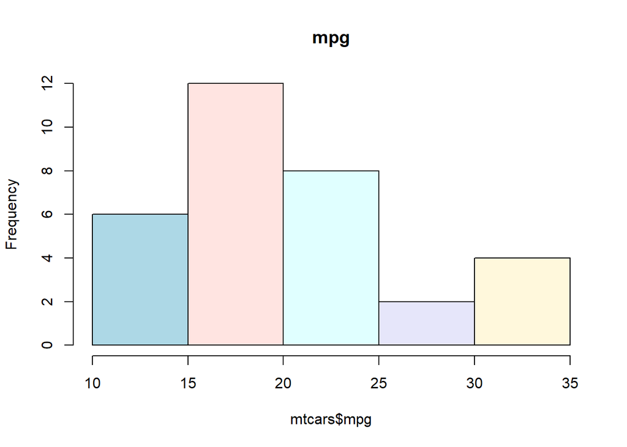

```r
# 연비(mpg)의 히스토그램을 그리시오.
hist(mtcars$mpg, main = 'mpg',
     col = c('lightblue', 'mistyrose','lightcyan','lavender','cornsilk','pink'))
```

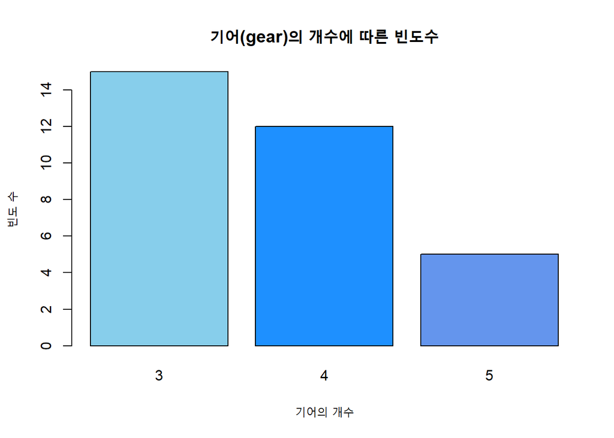

```r
# 기어(gear)의 개수에 따른 빈도수를 나타내는 barplot을 그리시오.
mt.tb <- table(mtcars$gear)
barplot(mt.tb,
        col =  c('sky blue', 'Dodger Blue', 'cornflower blue'),
        main = '기어(gear)의 개수에 따른 빈도수',
        xlab = '기어의 개수',
        ylab = '빈도 수')
```

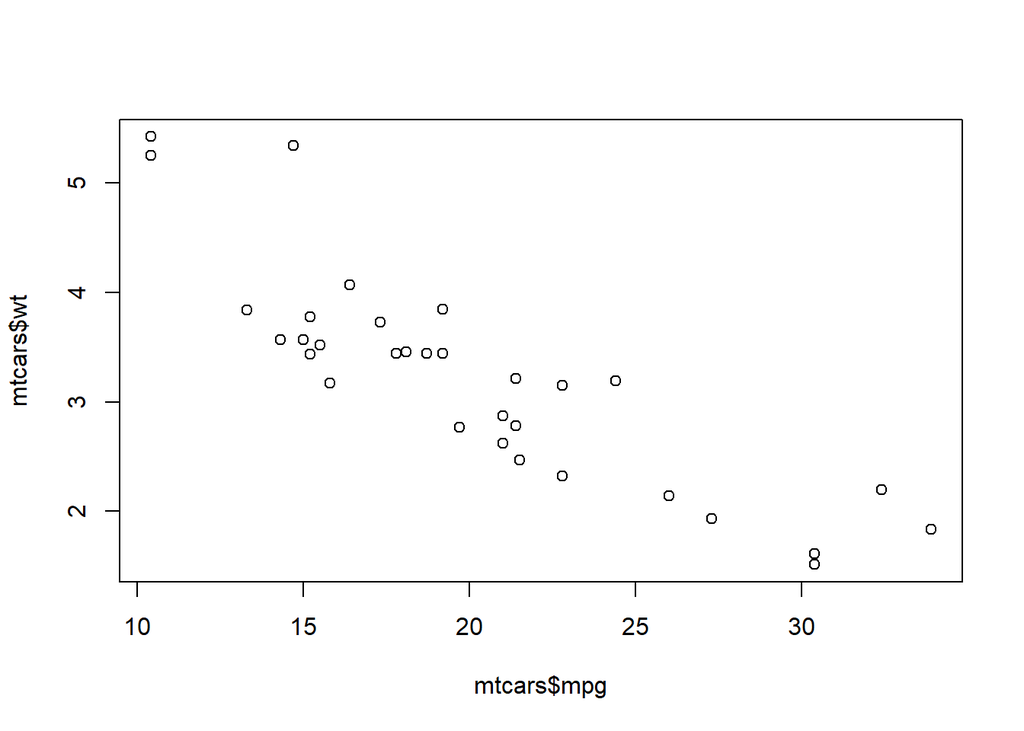

```r
# mpg와 wt와의 관계를 나타내는 산점도(scatter plot)를 그리시오.
plot(mtcars$mpg, mtcars$wt)
```

### 문제 3: state.x77 데이터셋

```r
# state.x77 데이터셋의 각 변수값에 대해 조사하시오.
?state.x77
```

```
## starting httpd help server ... done
```

```r
# state.x77 데이터셋의 데이터 프레임을 분석하시오.
st <- as.data.frame(state.x77)

# state.x77 데이터셋의 각 변수별 기술적 통계량을 분석하시오.
summary(st)
```

```
##    Population        Income       Illiteracy       Life Exp
##  Min.   :  365   Min.   :3098   Min.   :0.500   Min.   :67.96
##  1st Qu.: 1080   1st Qu.:3993   1st Qu.:0.625   1st Qu.:70.12
##  Median : 2838   Median :4519   Median :0.950   Median :70.67
##  Mean   : 4246   Mean   :4436   Mean   :1.170   Mean   :70.88
##  3rd Qu.: 4968   3rd Qu.:4814   3rd Qu.:1.575   3rd Qu.:71.89
##  Max.   :21198   Max.   :6315   Max.   :2.800   Max.   :73.60
##      Murder          HS Grad          Frost             Area
##  Min.   : 1.400   Min.   :37.80   Min.   :  0.00   Min.   :  1049
##  1st Qu.: 4.350   1st Qu.:48.05   1st Qu.: 66.25   1st Qu.: 36985
##  Median : 6.850   Median :53.25   Median :114.50   Median : 54277
##  Mean   : 7.378   Mean   :53.11   Mean   :104.46   Mean   : 70736
##  3rd Qu.:10.675   3rd Qu.:59.15   3rd Qu.:139.75   3rd Qu.: 81163
##  Max.   :15.100   Max.   :67.30   Max.   :188.00   Max.   :566432
```

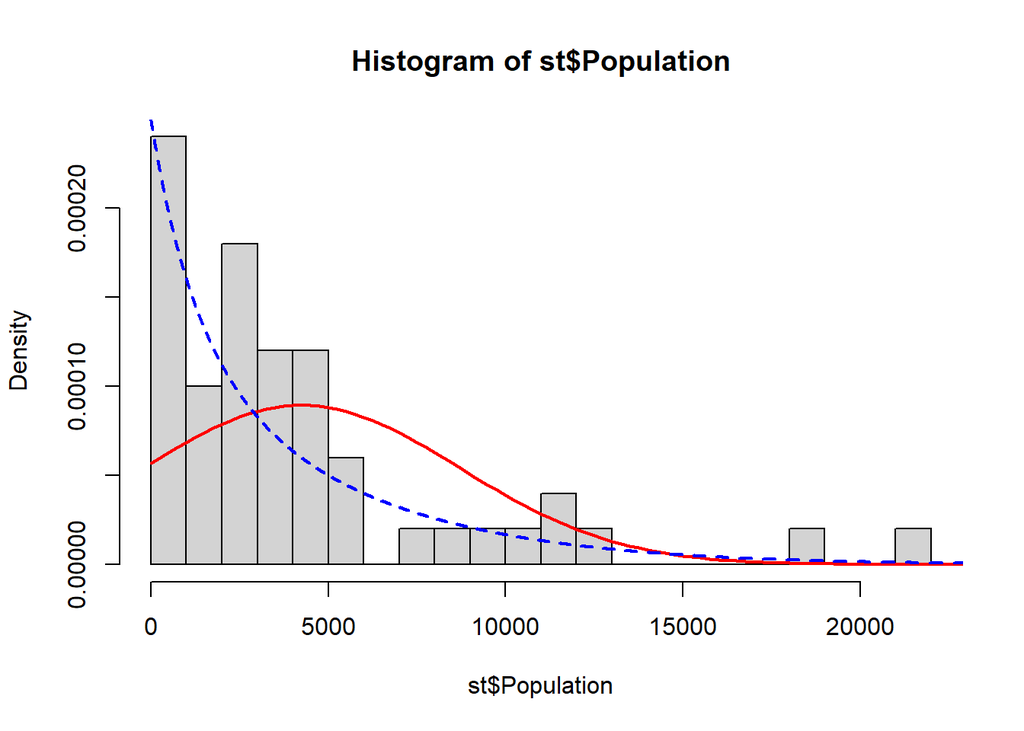

```r
# 정규분포를 따르는 것과 따르지 않는 것 하나 보여주기!!
# state.x77 데이터셋의 각 변수별 확률분포를 시각화하시오.

# 1. Population
hist(st$Population, breaks = 25, prob = T)

# 정규분포 곡선 (dnorm : 정규분포)
x <- seq(0, 25000, length(10000))
curve(dnorm(x, 4246, sd(st$Population)), 0, 25000,
      add = T, col = 'red', lwd= 2)

# 지수분포 그래프
lambda <- 0.00025
y <- lambda * exp(-lambda * x)
lines(x, dexp(x, y), col = 'blue', lwd=2, lty = 2)
```

##### 📍 정규분포를 따르지 않음

##### 💡 지수분포를 따르는 것으로 보임

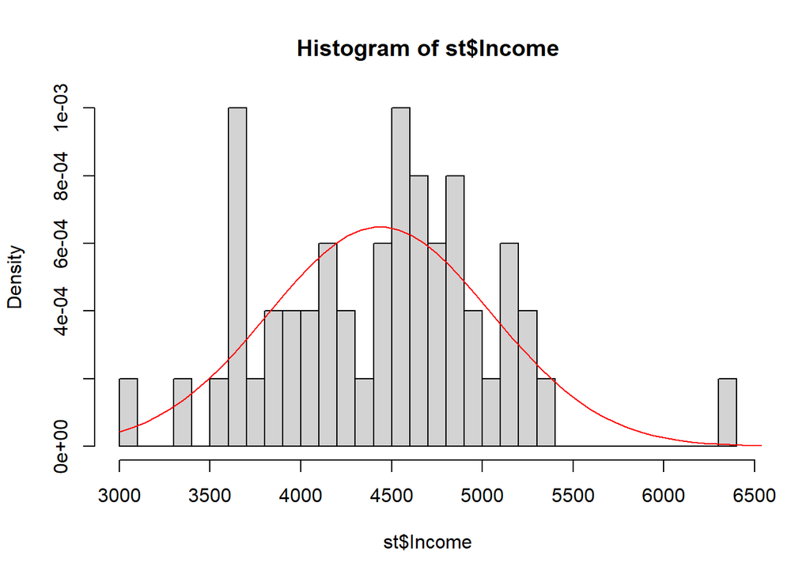

```r
## 2. Income
hist(st$Income, breaks = 25, prob = T)
x <- seq(3000, 10000, length(10000))
curve(dnorm(x, mean(st$Income), sd(st$Income)),3000, 10000,
      add = T, col = 'red')
```

##### 💡 정규분포를 따름

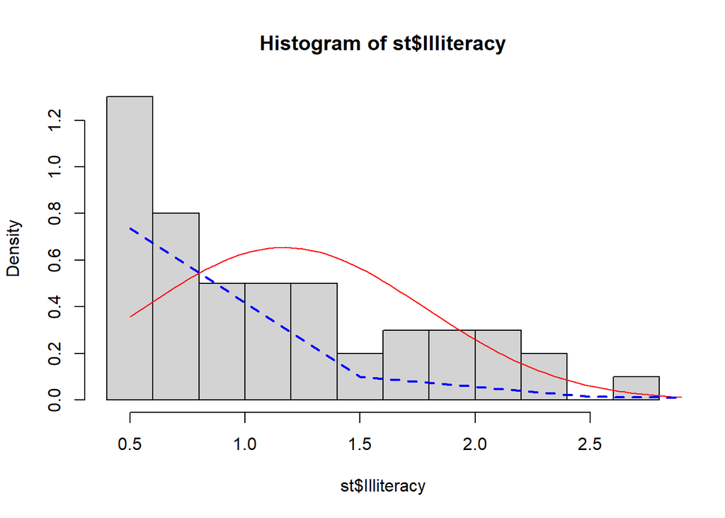

```r
## 3. Illiteracy
hist(st$Illiteracy, breaks = 10, prob = T)

# 정규분포 그래프
x <- seq(0.5, 4.0, length(100))
curve(dnorm(x, mean(st$Illiteracy), sd(st$Illiteracy)),0.5, 3.0,
      add = T, col = 'red')

# 지수분포 그래프
lambda <- 2
y <- lambda * exp(-lambda * x)
lines(x, dexp(x, 2), col = 'blue', lwd=2, lty = 2)
```

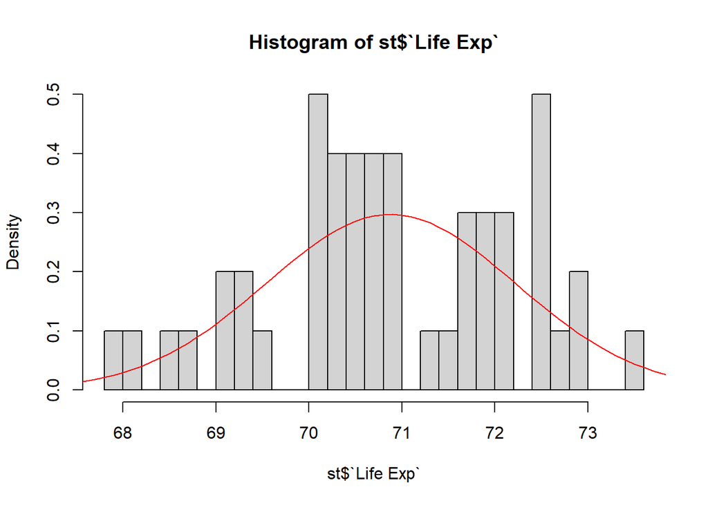

```r
## 4. Life Exp
hist(st$`Life Exp`, breaks = 25, prob = T)
x <- seq(65, 75, length(100))
curve(dnorm(x, mean(st$`Life Exp`), sd(st$`Life Exp`)),65, 75,
      add = T, col = 'red')
```

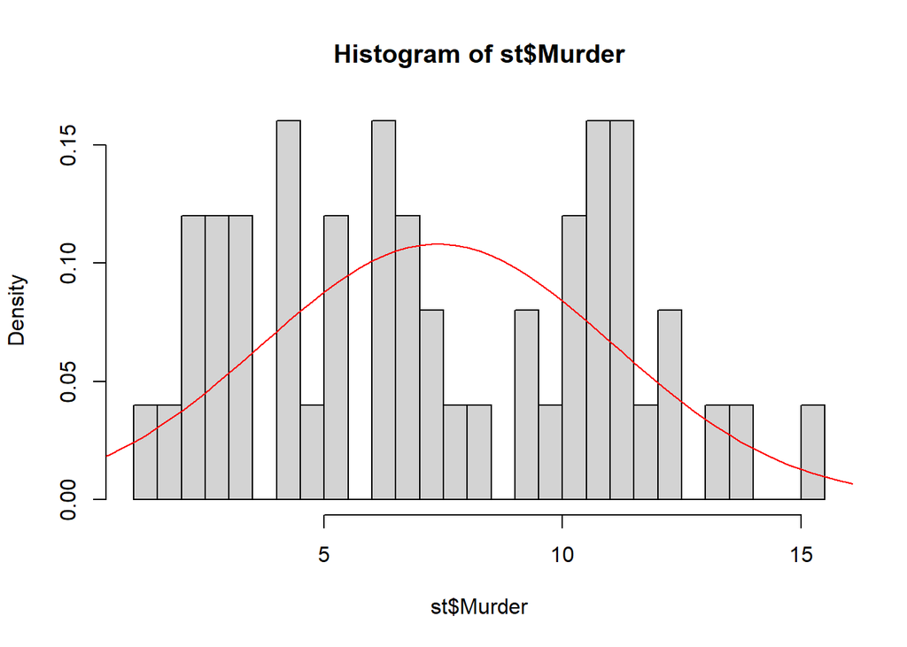

```r
## 4. Murder
hist(st$Murder, breaks = 25, prob = T)
x <- seq(0, 20, length(100))
curve(dnorm(x, mean(st$Murder), sd(st$Murder)),0, 25,
      add = T, col = 'red')
```

##### 👉 그외 HS Grad, Frost, Area 변수들이 있음

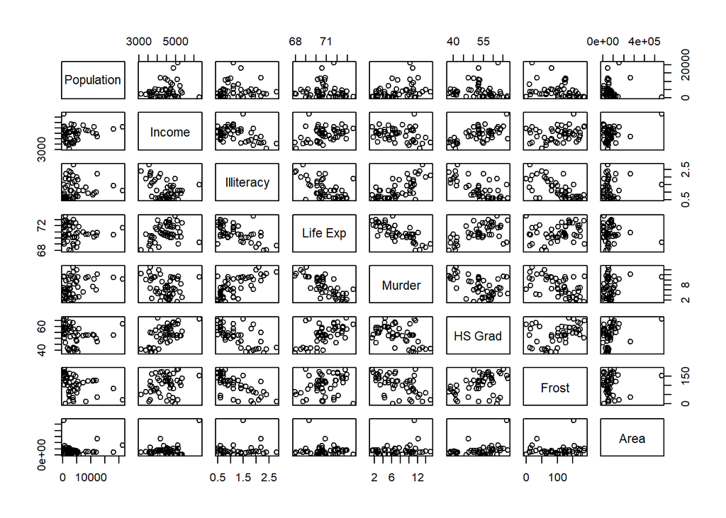

```r
# state.x77 데이터셋의 각 변수간의 관계에 대해 분석하고 시각화하시오.
plot(st)
```

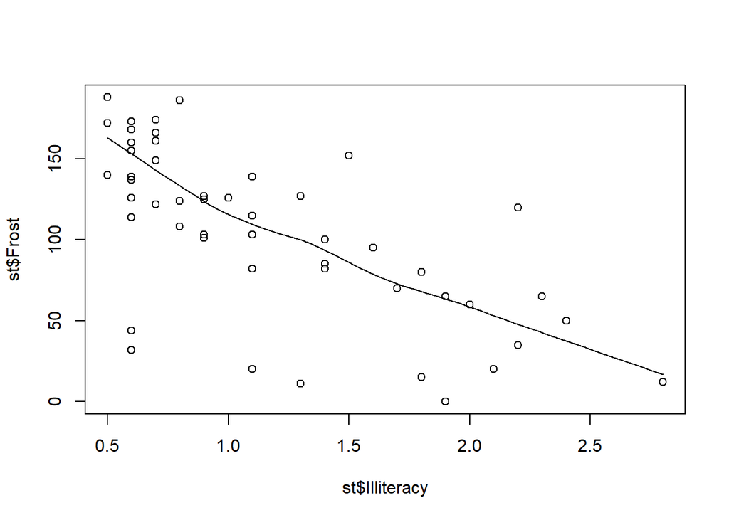

```r
scatter.smooth(st$Illiteracy,st$Frost)
```

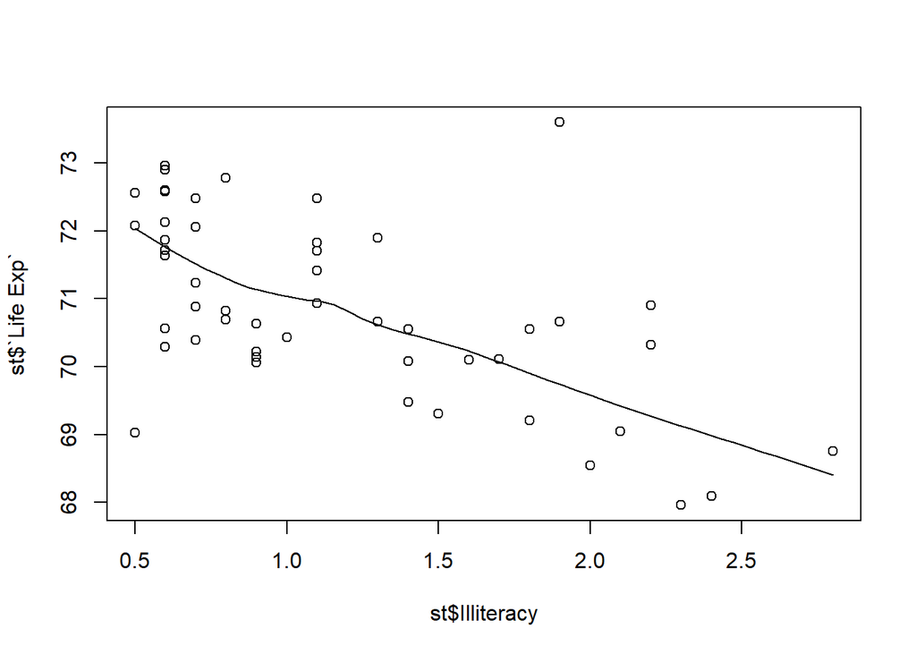

```r
scatter.smooth(st$Illiteracy,st$`Life Exp`)
```

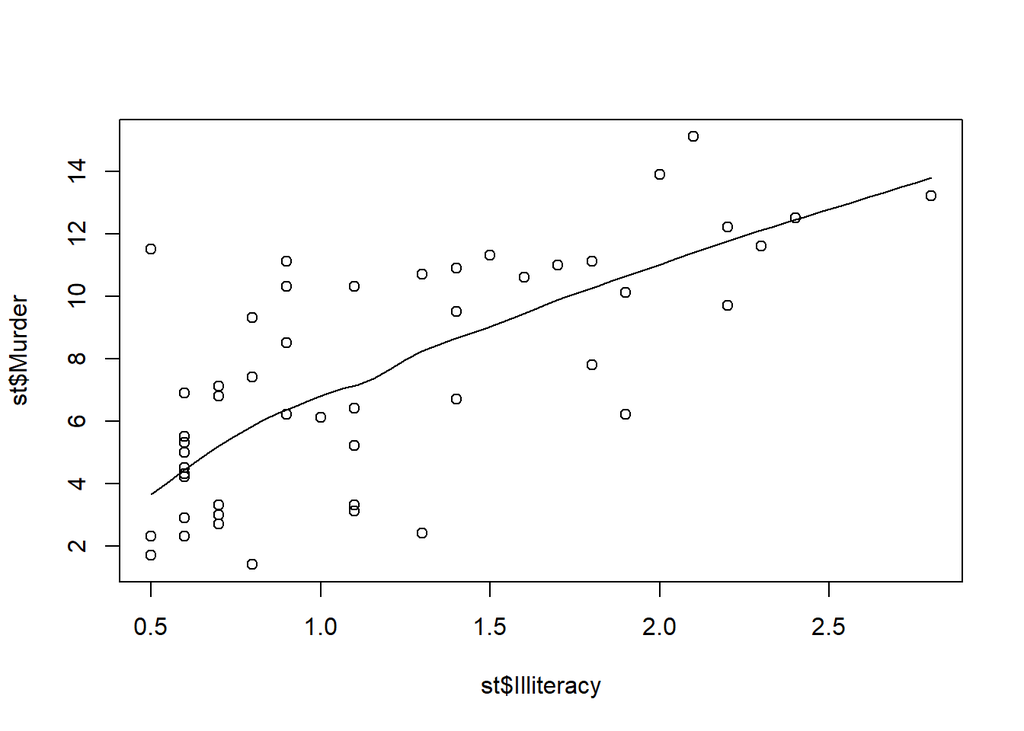

```r
scatter.smooth(st$Illiteracy,st$Murder)
```

```r
# state.x77 데이터셋을 대상으로 통계적 분석을 실행하고
# 통계적 분석을 통해 얻은 분석 결과를 기술하시오.
# 예) 변수간 상관관계가 가장 높은 두 변수는 Murder와 Illiteracy이다.
# 상관계수, 선형회귀식
# 상관계수(수치)
cor_r <- round(cor(st),1)
cor_r
```

```
##            Population Income Illiteracy Life Exp Murder HS Grad Frost Area
## Population        1.0    0.2        0.1     -0.1    0.3    -0.1  -0.3  0.0
## Income            0.2    1.0       -0.4      0.3   -0.2     0.6   0.2  0.4
## Illiteracy        0.1   -0.4        1.0     -0.6    0.7    -0.7  -0.7  0.1
## Life Exp         -0.1    0.3       -0.6      1.0   -0.8     0.6   0.3 -0.1
## Murder            0.3   -0.2        0.7     -0.8    1.0    -0.5  -0.5  0.2
## HS Grad          -0.1    0.6       -0.7      0.6   -0.5     1.0   0.4  0.3
## Frost            -0.3    0.2       -0.7      0.3   -0.5     0.4   1.0  0.1
## Area              0.0    0.4        0.1     -0.1    0.2     0.3   0.1  1.0
```

```r
## 0.9 이상 : 매우 높은 상관관계 (0)
sum(abs(cor_r) >= 0.9 & abs(cor_r) != 1 )/2
```

```
## [1] 0
```

```r
## 0.9 ~ 0.7 : 높은 상관관계 (4)
sum(abs(cor_r) < 0.9 & abs(cor_r) >= 0.7 )/2
```

```
## [1] 4
```

```r
## 0.7 ~ 0.4 : 다소 높은 상관관계 (8)
sum(abs(cor_r) < 0.7 & abs(cor_r) >= 0.4 )/2
```

```
## [1] 8
```

```r
## 0.4 ~ 0.2 : 낮은 상관관계 (9)
sum(abs(cor_r) < 0.4 & abs(cor_r) >= 0.2 )/2
```

```
## [1] 9
```

```r
## 0.2 미만 : 상관관계 없음 (7)
sum(abs(cor_r) < 0.2)/2
```

```
## [1] 7
```

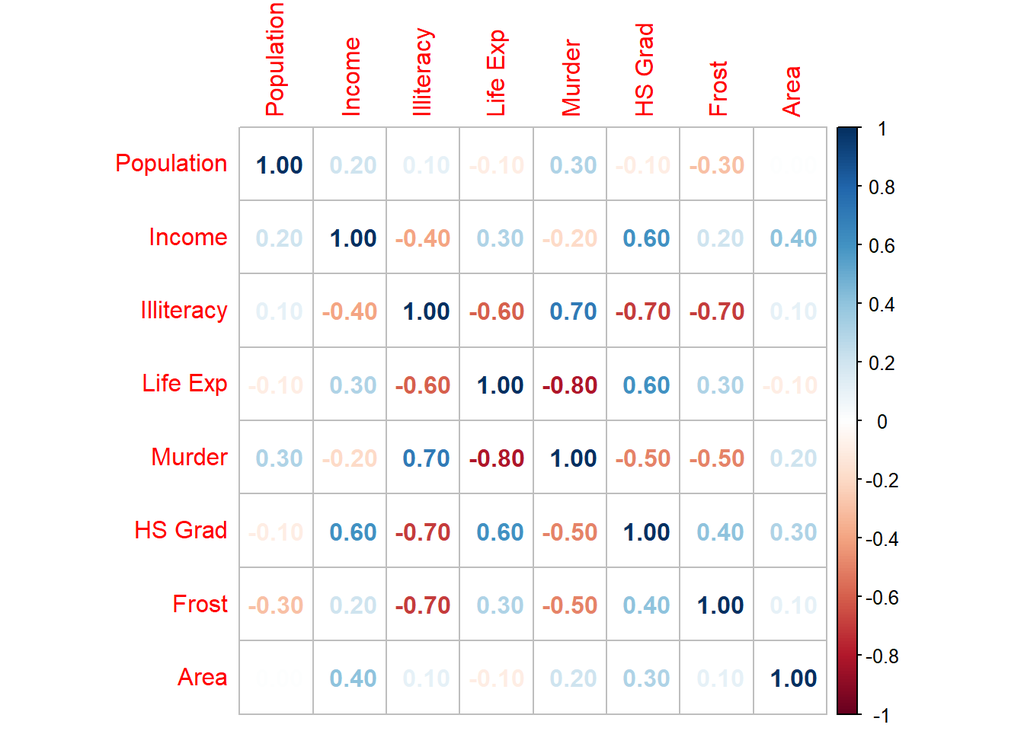

```r
# 상관계수 (시각적)
library(corrplot)
corrplot(cor_r, method='number')
```

##### 변수간 상관계수가 0.7이상인 높은 상관관계를 띄는 두 변수는

##### 양의 상관계수 : Illiteracy Murder (0.7)

##### 음의 상관계수 : Illiteracy HS Grad (-0.7), Illiteracy Frost (-0.7), Life Exp Murder (-0.8)

#### 다중회귀모델

- 다중회귀는 단순회귀분석과 달리 예측변수가 두 개 이상인 경우에 사용한다. 다중회귀분석에서 예측변수의 수가 많을 경우 사용
- 이 데이터의 경우 x (설명변수, 독립변수 - 원인이 되는 변수)가 하나가 아니라 여러개 이므로 다중선형회귀를 사용해야함
- 종속변수 : 살인률
- 독립변수 (설명변수) : 인구, 수입, 문맹률, 결빙일수

```r
states <- as.data.frame(state.x77[,c("Murder","Population","Illiteracy", "Income","Frost")])
states['rich'] <- ifelse(mean(states$Income) < states$Income, 1, 0)

# 숫자형으로 되어 있으므로 factor 형식으로 바꾸어 주기
# class(states$rich)
states$rich <- factor(states$rich)

fit <- lm(Murder ~ ., data=states)
fit
```

```
##
## Call:
## lm(formula = Murder ~ ., data = states)
##
## Coefficients:
## (Intercept)   Population   Illiteracy       Income        Frost        rich1
##  -2.8261867    0.0002403    3.7687923    0.0014496   -0.0032135   -2.2757715
```

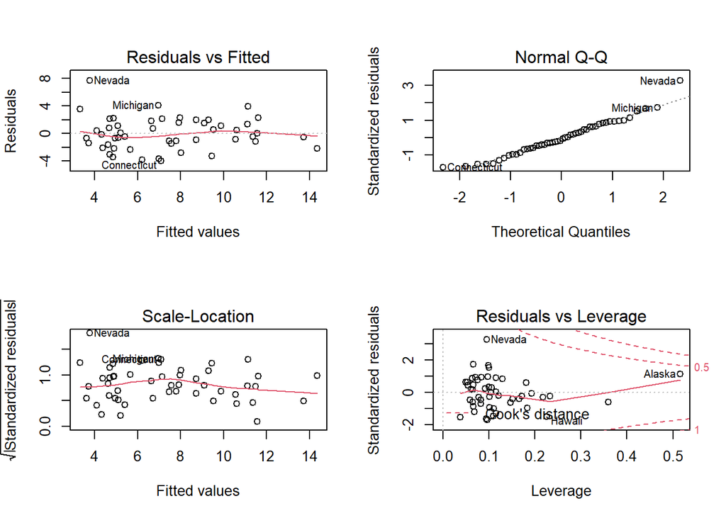

```r
par(mfrow=c(2,2))
plot(fit) # 선형성, 정규성, 등분산성 모두 만족
```

###### : 빨간 실선은 잔차의 추세를 나타내며 빨간 실선이 점선에서 크게 벗어난다면 예측값에 따라 잔차가 크게 달라짐

###### : 잔차가 정규분포를 띄면 점들이 점선을 따라 배치 되어 있어야 함

```r
summary(fit)
```

```
##
## Call:
## lm(formula = Murder ~ ., data = states)
##
## Residuals:
##     Min      1Q  Median      3Q     Max
## -3.9942 -1.4528 -0.2696  1.5673  7.7162
##
## Coefficients:
##               Estimate Std. Error t value Pr(>|t|)
## (Intercept) -2.826e+00  4.403e+00  -0.642   0.5243
## Population   2.403e-04  8.886e-05   2.704   0.0097 **
## Illiteracy   3.769e+00  8.788e-01   4.288 9.69e-05 ***
## Income       1.450e-03  1.022e-03   1.419   0.1630
## Frost       -3.213e-03  1.004e-02  -0.320   0.7505
## rich1       -2.276e+00  1.271e+00  -1.791   0.0802 .
## ---
## Signif. codes:  0 '***' 0.001 '**' 0.01 '*' 0.05 '.' 0.1 ' ' 1
##
## Residual standard error: 2.475 on 44 degrees of freedom
## Multiple R-squared:  0.5964, Adjusted R-squared:  0.5505
## F-statistic:    13 on 5 and 44 DF,  p-value: 8.704e-08
```

- summary를 했을 때 Population, Illiteracy는 p-value값이 0.05보다 작아서 유의하지만, 나머지 변수는 유의하지 않음을 알 수 있음

```r
# 각각의 산점도와 다중공성성
library(psych)
library(car)
```

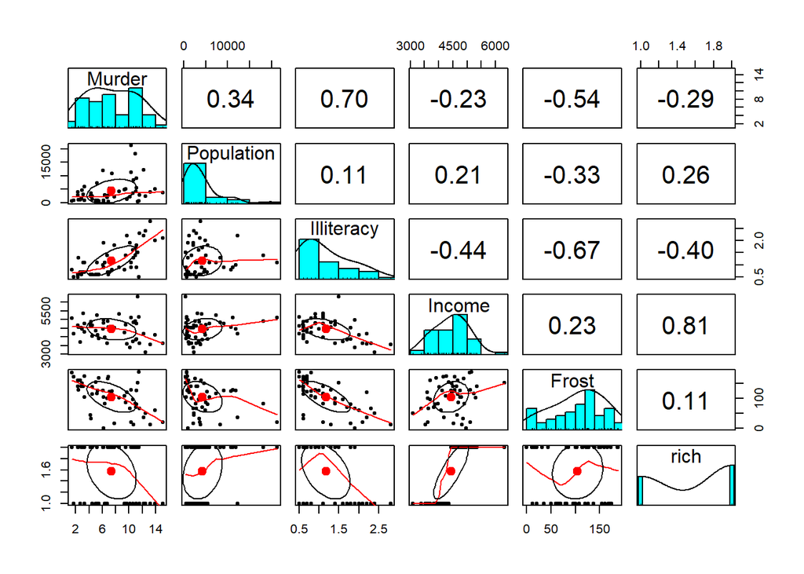

```r
# 각각 모든 변수들간 산점도 그리기
# 다중공선성 - 다중회귀분석에서 x변수(설명변수, 독립변수)들 끼리 상관관계가 존재할 경우
# 회귀 계수의 분산을 크게하여, 회귀분석 시 추정 회귀 계수를 믿을 수 없게 되는 문제.
pairs.panels(states[names(states)])
```

- 위 그래프에서 숫자는 상관관계를 나타내며, -1에 가까우면 음의 상관관계, 1에 가까우면 양의 상관관계를 의미함
- 위 그래프에서 나타난 값 중 0.81, 0.70과 같이 1에 가까운 수가 있으므로 다중공선성이 의심됨

```r
# 다중공선성 확인
# 'sqrt(car::vif(fit))' 가 2보다 크면 다중공선성이 있는 것!!
sqrt(car::vif(fit)) > 2
```

```
## Population Illiteracy     Income      Frost       rich
##      FALSE      FALSE      FALSE      FALSE      FALSE
```

- 위에서는 모두 false이므로 다중공선성이 없다고 판단할 수 있음
- 다중선형회귀분석을 할때 회귀모형에서 어떤 x변수(설명변수)를 어떻게 선택해야 하는지 알 수 있음
- 설명변수가 유의하지 않다고 해서 한번에 다 제거해서는 안됨
- 단계별로 하나씩 제거해야하고, 하나씩 제거하다 보면 유의하지 않았던 변수가 유의해 질 수도 있음

#### 1. 전진 선택법 (forward)

- 상수항만 포함시킨 회귀모형에서 설명변수를 하나씩 추가하는 방법
- 먼저 상수항만 포함된 회귀모형을 만들어 줌

```r
fit.con <- lm(Murder~1,data=states)

# 이제 'step'이라는 함수를 이용하여 유의한 설명변수를 추출합니다.
# *AIC가 작은 것을 기준으로 추출합니다.
fit.forward <- step(fit.con,scope=list(lower=fit.con,upper=fit),
                    direction = "forward")
```

```
## Start:  AIC=131.59
## Murder ~ 1
##
##              Df Sum of Sq    RSS     AIC
## + Illiteracy  1    329.98 337.76  99.516
## + Frost       1    193.91 473.84 116.442
## + Population  1     78.85 588.89 127.311
## + rich        1     57.49 610.26 129.093
## + Income      1     35.35 632.40 130.875
## <none>                    667.75 131.594
##
## Step:  AIC=99.52
## Murder ~ Illiteracy
##
##              Df Sum of Sq    RSS     AIC
## + Population  1    48.517 289.25  93.763
## <none>                    337.76  99.516
## + Frost       1     5.387 332.38 100.712
## + Income      1     4.916 332.85 100.783
## + rich        1     0.061 337.70 101.507
##
## Step:  AIC=93.76
## Murder ~ Illiteracy + Population
##
##          Df Sum of Sq    RSS    AIC
## <none>                289.25 93.763
## + rich    1    7.3399 281.91 94.477
## + Income  1    0.0570 289.19 95.753
## + Frost   1    0.0214 289.22 95.759
```

```r
# 정말 유의한지 안한지는 summary를 통해서 알아봐야함
summary(fit.forward)
```

```
##
## Call:
## lm(formula = Murder ~ Illiteracy + Population, data = states)
##
## Residuals:
##     Min      1Q  Median      3Q     Max
## -4.7652 -1.6561 -0.0898  1.4570  7.6758
##
## Coefficients:
##              Estimate Std. Error t value Pr(>|t|)
## (Intercept) 1.652e+00  8.101e-01   2.039  0.04713 *
## Illiteracy  4.081e+00  5.848e-01   6.978 8.83e-09 ***
## Population  2.242e-04  7.984e-05   2.808  0.00724 **
## ---
## Signif. codes:  0 '***' 0.001 '**' 0.01 '*' 0.05 '.' 0.1 ' ' 1
##
## Residual standard error: 2.481 on 47 degrees of freedom
## Multiple R-squared:  0.5668, Adjusted R-squared:  0.5484
## F-statistic: 30.75 on 2 and 47 DF,  p-value: 2.893e-09
```

##### 💡 인구수와 문맹률 모두 유의함을 알 수 있음

#### 2. 후진 제거법 (backward)

- 모든 변수를 포함시킨 모형에서 하나씩 제거해 나가는 방법

```r
fit.backward <- step(fit,scope=list(lower=fit.con,upper=fit),
                     direction = "backward")
```

```
## Start:  AIC=96.23
## Murder ~ Population + Illiteracy + Income + Frost + rich
##
##              Df Sum of Sq    RSS     AIC
## - Frost       1     0.627 270.15  94.347
## <none>                    269.52  96.231
## - Income      1    12.332 281.85  96.468
## - rich        1    19.649 289.17  97.749
## - Population  1    44.792 314.31 101.918
## - Illiteracy  1   112.648 382.17 111.692
##
## Step:  AIC=94.35
## Murder ~ Population + Illiteracy + Income + rich
##
##              Df Sum of Sq    RSS     AIC
## <none>                    270.15  94.347
## - Income      1    11.760 281.91  94.477
## - rich        1    19.043 289.19  95.753
## - Population  1    53.175 323.32 101.331
## - Illiteracy  1   214.233 484.38 121.542
```

```r
summary(fit.backward)
```

```
##
## Call:
## lm(formula = Murder ~ Population + Illiteracy + Income + rich,
##     data = states)
##
## Residuals:
##     Min      1Q  Median      3Q     Max
## -4.0708 -1.5594 -0.1855  1.5541  7.6033
##
## Coefficients:
##               Estimate Std. Error t value Pr(>|t|)
## (Intercept) -3.231e+00  4.175e+00  -0.774  0.44297
## Population   2.491e-04  8.368e-05   2.976  0.00468 **
## Illiteracy   3.951e+00  6.615e-01   5.974 3.41e-07 ***
## Income       1.397e-03  9.984e-04   1.400  0.16848
## rich1       -2.190e+00  1.230e+00  -1.781  0.08166 .
## ---
## Signif. codes:  0 '***' 0.001 '**' 0.01 '*' 0.05 '.' 0.1 ' ' 1
##
## Residual standard error: 2.45 on 45 degrees of freedom
## Multiple R-squared:  0.5954, Adjusted R-squared:  0.5595
## F-statistic: 16.56 on 4 and 45 DF,  p-value: 2.068e-08
```

##### 💡 최종적으로 인구수, 문맹률, 수입, rich 추출됨

##### 💡 인구수와 문맹률만 유의함을 알 수 있음

#### 3. 단계별 선택법 (stepwise)

- stepwise는 전진선택과 후진제거를 왔다갔다하며 모두 쓰는 방법

```r
# 우선 상수항만을 포함하고 있는 모형에서 시작해 보겠습니다.
fit.both <- step(fit.con,scope=list(lower=fit.con,upper=fit), direction = "both")
```

```
## Start:  AIC=131.59
## Murder ~ 1
##
##              Df Sum of Sq    RSS     AIC
## + Illiteracy  1    329.98 337.76  99.516
## + Frost       1    193.91 473.84 116.442
## + Population  1     78.85 588.89 127.311
## + rich        1     57.49 610.26 129.093
## + Income      1     35.35 632.40 130.875
## <none>                    667.75 131.594
##
## Step:  AIC=99.52
## Murder ~ Illiteracy
##
##              Df Sum of Sq    RSS     AIC
## + Population  1     48.52 289.25  93.763
## <none>                    337.76  99.516
## + Frost       1      5.39 332.38 100.712
## + Income      1      4.92 332.85 100.783
## + rich        1      0.06 337.70 101.507
## - Illiteracy  1    329.98 667.75 131.594
##
## Step:  AIC=93.76
## Murder ~ Illiteracy + Population
##
##              Df Sum of Sq    RSS     AIC
## <none>                    289.25  93.763
## + rich        1     7.340 281.91  94.477
## + Income      1     0.057 289.19  95.753
## + Frost       1     0.021 289.22  95.759
## - Population  1    48.517 337.76  99.516
## - Illiteracy  1   299.646 588.89 127.311
```

```r
summary(fit.both)
```

```
##
## Call:
## lm(formula = Murder ~ Illiteracy + Population, data = states)
##
## Residuals:
##     Min      1Q  Median      3Q     Max
## -4.7652 -1.6561 -0.0898  1.4570  7.6758
##
## Coefficients:
##              Estimate Std. Error t value Pr(>|t|)
## (Intercept) 1.652e+00  8.101e-01   2.039  0.04713 *
## Illiteracy  4.081e+00  5.848e-01   6.978 8.83e-09 ***
## Population  2.242e-04  7.984e-05   2.808  0.00724 **
## ---
## Signif. codes:  0 '***' 0.001 '**' 0.01 '*' 0.05 '.' 0.1 ' ' 1
##
## Residual standard error: 2.481 on 47 degrees of freedom
## Multiple R-squared:  0.5668, Adjusted R-squared:  0.5484
## F-statistic: 30.75 on 2 and 47 DF,  p-value: 2.893e-09
```

##### 💡 최종적으로 문맹률과 인구수가 추출되었으며, 모두 유의한것을 알 수 있음

```r
# 회귀방정식
coef(fit.both)
```

```
##  (Intercept)   Illiteracy   Population
## 1.6515497424 4.0807366362 0.0002241861
```

##### 💡 최종 회귀방정식 : y = 1.6515497 + 4.0807366 * Illiteracy + 0.0002242 * Population

```r
# 마지막으로 지금까지 새운 모델로 살인률(y, 종속변수)을 예측
# pridict 함수를 이용해서 예측하고, 보기좋게 data frame 형태로 바꿔줌
## 점추정
pre_murder <- predict(fit.both, newdata = states)
pre_murder <- as.data.frame(pre_murder)
pre_murder
```

```
##                pre_murder
## Alabama         11.031529
## Alaska           7.854483
## Arizona          9.492775
## Arkansas         9.877982
## California      10.892657
## Colorado         5.077722
## Connecticut      6.835337
## Delaware         5.454016
## Florida          8.812096
## Georgia         10.918485
## Hawaii           9.599543
## Idaho            4.282255
## Illinois         7.834425
## Indiana          5.699166
## Iowa             4.333315
## Kansas           4.611136
## Kentucky         8.940047
## Louisiana       13.930865
## Maine            4.745254
## Maryland         6.248308
## Massachusetts    7.443778
## Michigan         7.366772
## Minnesota        4.979025
## Mississippi     11.970137
## Missouri         5.984834
## Montana          4.267235
## Nebraska         4.446135
## Nevada           3.824188
## New Hampshire    4.690105
## New Jersey       7.784317
## New Mexico      10.885639
## New York        11.416969
## North Carolina  10.216672
## North Dakota     5.058946
## Ohio             7.322777
## Oklahoma         6.749025
## Oregon           4.612033
## Pennsylvania     8.391134
## Rhode Island     7.165225
## South Carolina  11.668552
## South Dakota     3.844589
## Tennessee        9.524331
## Texas           13.372536
## Utah             4.369688
## Vermont          4.205808
## Virginia         8.481252
## Washington       4.897870
## West Virginia    7.767892
## Wisconsin        5.536855
## Wyoming          4.184286
```

###### 각 주별로 (각 행 별로) 예측된 살인율을 확인 할 수 있음

```r
## 구간추정을 해보겠습니다.
pre_murder <- predict(fit.both, newdata = states, interval = "confidence")
pre_murder <- as.data.frame(pre_murder)
pre_murder
```

```
##                      fit       lwr       upr
## Alabama        11.031529  9.716444 12.346615
## Alaska          7.854483  6.810613  8.898352
## Arizona         9.492775  8.394405 10.591146
## Arkansas        9.877982  8.687628 11.068336
## California     10.892657  8.070037 13.715277
## Colorado        5.077722  4.157763  5.997681
## Connecticut     6.835337  6.103519  7.567155
## Delaware        5.454016  4.502294  6.405739
## Florida         8.812096  7.853265  9.770927
## Georgia        10.918485  9.718215 12.118755
## Hawaii          9.599543  8.322616 10.876470
## Idaho           4.282255  3.199489  5.365021
## Illinois        7.834425  6.448128  9.220721
## Indiana         5.699166  4.775246  6.623087
## Iowa            4.333315  3.269718  5.396911
## Kansas          4.611136  3.610130  5.612142
## Kentucky        8.940047  8.052270  9.827823
## Louisiana      13.930865 11.879067 15.982662
## Maine           4.745254  3.742646  5.747863
## Maryland        6.248308  5.474960  7.021656
## Massachusetts   7.443778  6.686958  8.200598
## Michigan        7.366772  6.242934  8.490611
## Minnesota       4.979025  4.007930  5.950121
## Mississippi    11.970137 10.302442 13.637833
## Missouri        5.984834  5.146713  6.822955
## Montana         4.267235  3.179661  5.354808
## Nebraska        4.446135  3.409985  5.482285
## Nevada          3.824188  2.655956  4.992420
## New Hampshire   4.690105  3.669048  5.711161
## New Jersey      7.784317  6.912821  8.655812
## New Mexico     10.885639  9.354338 12.416940
## New York       11.416969  9.098230 13.735708
## North Carolina 10.216672  9.190172 11.243173
## North Dakota    5.058946  4.074351  6.043541
## Ohio            7.322777  5.954739  8.690815
## Oklahoma        6.749025  5.999985  7.498066
## Oregon          4.612033  3.611183  5.612883
## Pennsylvania    8.391134  6.946709  9.835558
## Rhode Island    7.165225  6.258221  8.072229
## South Carolina 11.668552 10.124504 13.212600
## South Dakota    3.844589  2.682569  5.006608
## Tennessee       9.524331  8.581644 10.467018
## Texas          13.372536 11.561692 15.183380
## Utah            4.369688  3.313159  5.426217
## Vermont         4.205808  3.097705  5.313910
## Virginia        8.481252  7.720725  9.241779
## Washington      4.897870  3.926226  5.869515
## West Virginia   7.767892  6.902564  8.633219
## Wisconsin       5.536855  4.634932  6.438779
## Wyoming         4.184286  3.068669  5.299903
```

```r
# 얼마나 잘 예측했는지 실제값과 비교 작업실시
tmp <- cbind(pre_murder,states$Murder)
tmp2 <- tmp[tmp$lwr <= tmp$`states$Murder` & tmp$`states$Murder` <= tmp$upr,]

nrow(tmp) # 50
```

```
## [1] 50
```

```r
nrow(tmp2) # 18
```

```
## [1] 18
```

### 문제 4: 생활속의 통계학 연습문제 풀이

#### - 5장 -

##### 연습문제 22)

##### 숫자 1에서 100까지 적힌 카드가 들어 있는 주머니에서 임의로 한장을 꺼내어 나온 숫자를 확률변수 X라고 할 때, 물음에 답하라

```r
# (1) X의 확률함수를 구하라
p.x = 1/100 # x = 1:100

# (2) X의 평균과 분산 그리고 표준편차를 구하라
x <- seq(1, 100, length=100)

mean(x) # 50.5
```

```
## [1] 50.5
```

```r
var(x) # 841.6667
```

```
## [1] 841.6667
```

```r
sd(x) # 29.01149
```

```
## [1] 29.01149
```

##### 연습문제 29)

##### 한 중간 판매업자가 50개의 상품을 수입하였다. 이들 수입 상품 중 5개의 상품에 결합이 있으나 판매업자는 몇개의 상품에 결함이 있는지 모른다.

##### 판매업자는 수입 상품 중에서 10개를 임의로 뽑아 결합이 있는지 조사하기로 하였다.

##### 이때, 조사한 상품 중에서 결함이 있는 상품이 2개 이하이면 수입을 허용하기로 하였다.

##### 이 판매업자가 수입된 상품을 허용할 확률을 구하라

```r
# 방법 1
(choose(45,8)*choose(5,2)+choose(45,9)*choose(5,1)+choose(45,10))/choose(50,10)
```

```
## [1] 0.9517397
```

```r
# 방법 2
event <- c(rep('결함',5), rep('정상',45))
event
```

```
##  [1] "결함" "결함" "결함" "결함" "결함" "정상" "정상" "정상" "정상" "정상"
## [11] "정상" "정상" "정상" "정상" "정상" "정상" "정상" "정상" "정상" "정상"
## [21] "정상" "정상" "정상" "정상" "정상" "정상" "정상" "정상" "정상" "정상"
## [31] "정상" "정상" "정상" "정상" "정상" "정상" "정상" "정상" "정상" "정상"
## [41] "정상" "정상" "정상" "정상" "정상" "정상" "정상" "정상" "정상" "정상"
```

```r
count = 0
n_sim = 100000
set.seed(1)

for (i in 1:n_sim) {
    result <- sample(event, 10, replace = F)
    count <- ifelse(sum(result == "결함") < 3, count + 1, count)

}
count / n_sim  # 0.9517
```

```
## [1] 0.9517
```

#### - 6장 -

##### 연습문제 21)

##### 고교 3학년 학생 1,000명에게 실시한 모의고사에서 국어 점수 X와 수학 점수 Y는 각각 X~N(75,9), Y~N(68, 16)인 정규분포를 따르고, 이 두 성적은 서로 독립이라고 한다.

```r
# (1) 국어 점수가 82점 이상일 확률을 구하라
pnorm(82, 75, sqrt(9)) # 0.99
```

```
## [1] 0.9901847
```

```r
# (2) 두 과목의 점수의 합이 130점 이상, 150점 이하에 해당하는 학생 수를 구하라
pnorm(130, 75+68, sqrt(9+16))
```

```
## [1] 0.004661188
```

```r
pnorm(150, 75+68, sqrt(9+16))
```

```
## [1] 0.9192433
```

```r
round(0.9192433 - 0.004661188,3) * 1000 # 915명
```

```
## [1] 915
```

```r
# (3) 각 과목에서 상위 5% 안에 들어가기 위한 최소 점수를 구하라
qnorm(0.95, 75, sqrt(9)) # 국어 : 80점
```

```
## [1] 79.93456
```

```r
qnorm(0.95, 68, sqrt(16)) # 수학 : 75점
```

```
## [1] 74.57941
```

##### 예제 14)

##### 확률변수 X가 모수 n =50, p = 0.7인 이항분포를 따를 때 다음을 구하라.

- P(X<=39) = 0.9211, P(X<=32) = 0.2178

```r
# (1) 이항확률 P(33<=X<=39)
0.9211 - 0.2178 # 0.7033
```

```
## [1] 0.7033
```

```r
# (2) 정규근사에 의한 P(33<=X<=39)
mu = 50*0.7
v = 50*0.7*0.3

pnorm(39, mu, sqrt(v)) # 0.891478
```

```
## [1] 0.891478
```

```r
pnorm(33, mu, sqrt(v)) # 0.268547
```

```
## [1] 0.268547
```

```r
0.891478 - 0.268547 # 0.622931
```

```
## [1] 0.622931
```

### 문제 5: 생활속의 통계학 연습문제 풀이

#### - 7장 -

##### 예제 10)

##### 성인 남성의 키는 평균 173.38cm, 표준편차 5.75cm이고, 성인 여성의 키는 160.39cm, 표준편차 4.99cm라 한다.

##### 남성과 여성을 각각 150명씩 임의로 선정했을 때, 남성의 평균 키가 여성의 평균 키보다 14cm 이상 클 확률

```r
x = 173.38-160.39
s = 5.75^2/150+4.99^2/150
# P(X-Y>14)
p = (14-12.99)/0.62 # 1.63 -> 0.9484

1 - 0.9484 # 0.0516
```

```
## [1] 0.0516
```

##### 연습문제 12)

##### 우리나라 20세 이상 성인 남자의 혈중 콜레스테롤 수치는 mu = 198인 정규분포를 따름 25명을 무작위로 선정하여 콜레스테롤을 측정한 결과 m = 197, s = 3.45

```r
# (1) 표본평균 m에 대한 표본분포를 구하라
(x-198)/(3.45/5)~t(24)
```

```
## (x - 198)/(3.45/5) ~ t(24)
```

```r
# (2) 표본평균이 196.82와 199.18 사이일 근사확률을 구하라
z1 = (196.82-198)/(3.45/5)
z2 = (199.18-198)/(3.45/5)

pnorm(z2) - pnorm(z1) # 0.9
```

```
## [1] 0.9127609
```

```r
# (3) 표본평균이 상위 2.5%인 경계수치를 구하라
qnorm(0.025, 198, 3.45/5, lower.tail = F)
```

```
## [1] 199.3524
```

```r
qnorm(0.975, 198, 3.45/5) # 답 : 199.3524
```

```
## [1] 199.3524
```

#### - 8장 -

##### 연습문제 8)

##### 다음은 어느 직장에 근무하는 직원 20명에 대한 혈중 콜레스테롤 수치를 조사한 자료이다.

##### 이 직장에 근무하는 직원들의 콜레스테롤 수치는 분산이 400인 정규분포를 따른다고 할 때, 평균 콜레스테롤에 대한 95% 신뢰구간을 구하라

```r
library(BSDA)
x8 <-  c(193.27, 193.88, 253.26, 237.15, 188.83, 200.56, 274.31, 230.36, 212.08, 222.19, 198.48, 202.50, 215.35, 218.95, 233.16, 222.23, 218.53, 204.64, 206.72, 199.37)
z.test(x8, sigma.x = sqrt(400))  #  95% 신뢰구간 : 207.5258 225.0562 (mg/dL)
```

```
##
##  One-sample z-Test
##
## data:  x8
## z = 48.364, p-value < 2.2e-16
## alternative hypothesis: true mean is not equal to 0
## 95 percent confidence interval:
##  207.5258 225.0562
## sample estimates:
## mean of x
##   216.291
```

##### 연습문제 15)

##### 2014년에 한국소비자보호원은 서울 지역 자가 운전자 1000명을 대상으로 설문조사를 실시

##### 가짜 석유 또는 정량 미달 주유를 의심한 경험이 있는 소비자가 79.3%에 이르는 것

```r
phat  <-  0.793
n = 1000
s_90 = 1.645 * sqrt((phat * (1 - phat)) / n) # 0.021
sprintf('서울 지역 자가 운전자의 비율에 대한 90%% 신뢰구간 : %.3f, %.3f', phat - s_90, phat + s_90)
```

```
## [1] "서울 지역 자가 운전자의 비율에 대한 90% 신뢰구간 : 0.772, 0.814"
```